# Sonification for data accessibility

Connor French

4/14/2021

A few weeks ago my partner shared a [TED Talk](https://www.youtube.com/watch?v=-hY9QSdaReY) with me that changed how I conceptualize data communication. In it [Dr. Wanda Diaz Merced](https://www.ted.com/speakers/wanda_diaz_merced), an astronomer who lost her eyesight in her early twenties, discusses her journey back into science after this setback. A crucial technique helped her interpret hefty astronomy data sets- sonification. [Sonification turns data into sound](https://handbook.floeproject.org/sonification). It is analogous to data visualization, where both methods aim to communicate patterns and relationships within data clearly and efficiently. Not only did sonification make data accessible for Dr. Merced, it helped her uncover patterns obscured by visualizing graphs and charts.

There are [quite a few applications](https://www.techfak.uni-bielefeld.de/ags/ami/publications/media/Hermann2002-SFE.pdf) for sonification. The bing you get when an email lands in your inbox is one familiar example. The recognizable noise conveys a simple piece of information without requiring you to be sitting at the computer or staring at your phone. Representing large data sets gets a little more complicated.

Audio has multiple dimensions that can be exploited to represent information, including:

- pitch
- loudness
- duration
- spatial arrangement (e.g. stereo panning)

These can be combined to represent multiple data dimensions or used interchangeably to represent the same data in a new way. Best practices are still being formed and are often context-dependent on the user, but a great resource for the latest practices is the [Floe Inclusive Learning Design Handbook](https://handbook.floeproject.org/sonification).

A particular application that is relevant for folks who want to increase the accessibility of their publications is to sonify their existing data visualizations. Below are a few common examples. Each example is a visualization, followed by the sonification. I have chosen to represent values on the y-axis as changes in pitch, while time indicates change along the x-axis. To emphasize the change in time along the x-axis, I have added short white noise pulses for each data point along the x-axis. The listener is “reading” the plot from left to right.

A common data visualization technique for single variables is the histogram. These emphasize the distribution of the variable under consideration. Below, I’ve simulated data representing my mood 15 minutes before eating dinner over the last several weeks.

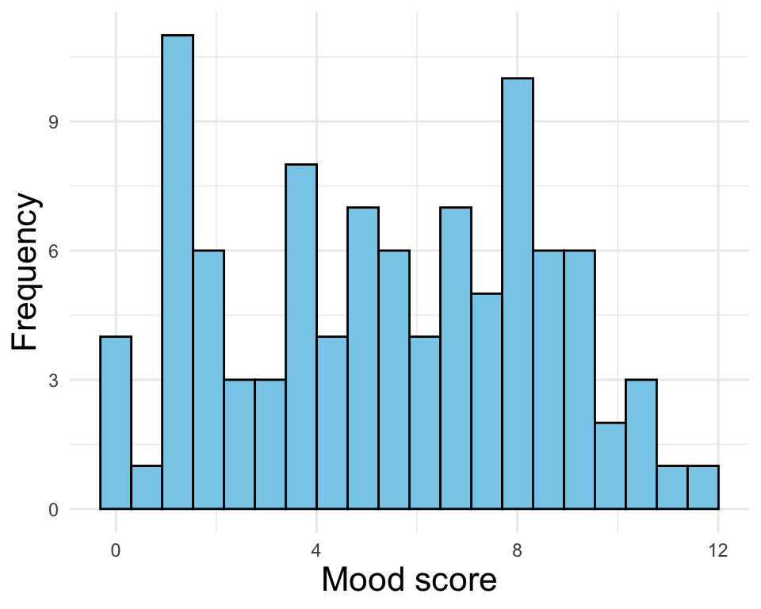

A histogram representing the distribution of mood score values.

[interactive chart not shown]

Notice how the pitch oscillates in a similar manner to the shape of the distribution and the pulses are evenly spaced, representing the bins of the distribution!

Example linear data

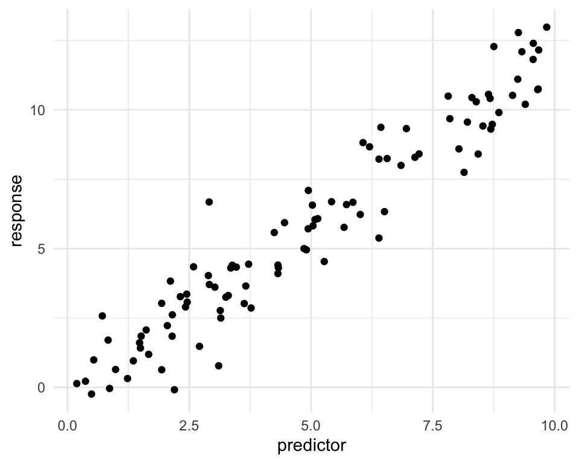

Linear sonification

Horizontal data

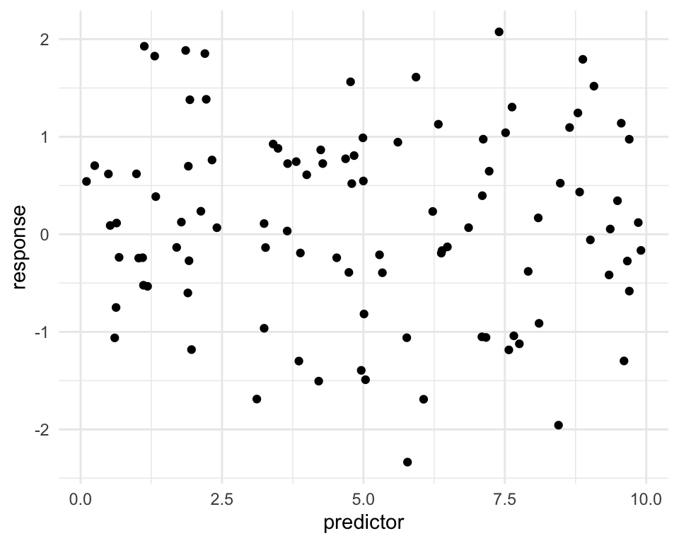

```r
set.seed(0987)
horizontal_data <- generate_data(beta = 0, error_sigma = 1)

horizontal_data %>%
  ggplot(aes(x = predictor, y = response)) +
  geom_point() +
  theme_minimal()
```

Horizontal sonification

Exponential data

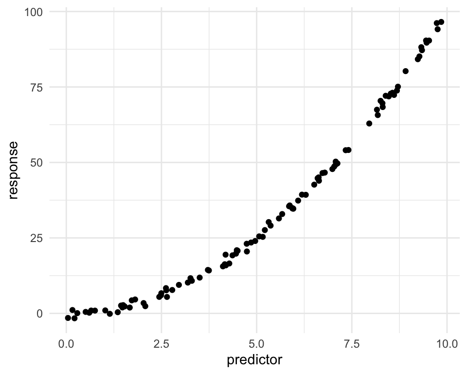

```r
expnt <- 2

exponential_data <- generate_data(is_exponential = TRUE, exponent = expnt)

exponential_data %>%
  ggplot(aes(x = predictor, y = response)) +
  geom_point() +
  theme_minimal()
```

Exponential sound

The sonifications were created using the R package [sonify](https://cran.r-project.org/web/packages/sonify/index.html).